# Statistical work

### Author - **Artem Hontarenko**

## Description

The goal of this work is to analyze the dataset of customer purchases. We will build and test some hypotheses and check the relations between different parts of the data using some statistical methods.

The dataset consists of information about the customers(e.g. age, income, education, etc.) and some details about their purchases(e.g. purchase_frequency, purchase_amount, etc.)

Source of data – https://www.kaggle.com/datasets/sanyamgoyal401/customer-purchases-behaviour-dataset

## Preparation

```python
#Importing the libraries
import pandas as pd
import numpy as np
import matplotlib.pyplot as plt
import seaborn as sns
import scipy.stats as stats
import statsmodels.api as sm
```

```python
#Declaration of the dataframe
df = pd.read_csv("data/customer_data.csv")
```

```python
#Cleaning of the data
del df['id']
```

```python
df
```

|  | age | gender | income | education | region | loyalty_status | purchase_frequency | purchase_amount | product_category | promotion_usage | satisfaction_score |
| --- | --- | --- | --- | --- | --- | --- | --- | --- | --- | --- | --- |
| 0 | 27 | Male | 40682 | Bachelor | East | Gold | frequent | 18249 | Books | 0 | 6 |
| 1 | 29 | Male | 15317 | Masters | West | Regular | rare | 4557 | Clothing | 1 | 6 |
| 2 | 37 | Male | 38849 | Bachelor | West | Silver | rare | 11822 | Clothing | 0 | 6 |
| 3 | 30 | Male | 11568 | HighSchool | South | Regular | frequent | 4098 | Food | 0 | 7 |
| 4 | 31 | Female | 46952 | College | North | Regular | occasional | 19685 | Clothing | 1 | 5 |
| ... | ... | ... | ... | ... | ... | ... | ... | ... | ... | ... | ... |
| 99995 | 31 | Female | 19691 | College | West | Regular | occasional | 7075 | Health | 0 | 7 |
| 99996 | 36 | Male | 17428 | HighSchool | South | Regular | rare | 6873 | Health | 0 | 5 |
| 99997 | 29 | Male | 13222 | College | West | Regular | frequent | 5152 | Clothing | 0 | 5 |
| 99998 | 31 | Female | 40093 | Bachelor | West | Regular | frequent | 16312 | Health | 1 | 5 |
| 99999 | 35 | Female | 22249 | College | West | Silver | rare | 9426 | Health | 0 | 6 |

100000 rows × 11 columns

## Part 1: Hypothesis testing with chi-square test

Let us look at the distribution of the age of the customers to gain an insight into the client base.

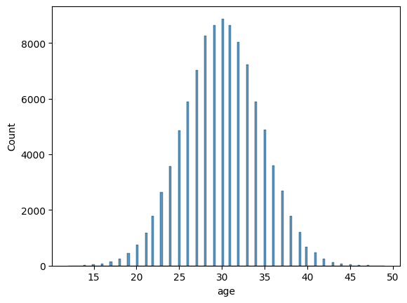

```python
sns.histplot(df['age'])
plt.show()
```

As we see, the distribution of the age is similar to the normal distribution, so we are ready to build the null hyphothesis and the alternative hyphothesis.

$H_0:$ *the distribution of the age of the cusomers is well modeled by normal distribution;*

$H_A:$ *the distribution of the age of the cusomers is **not** well modeled by normal distribution;*

The **significance level** in our testing is **0.05**.

```python
#Transforming the seriaes to array
age = df['age'].to_numpy()
#Computing the mean value, varience and standard deviation respectively
age_mean = np.mean(age)
age_var = np.var(age)
age_std = np.std(age)
```

To check the hyphothesis we split the data into intervals to compute Z-score for every interval. Then we compute the CDF for every Z-score.Using the CDF we compute the expected area inside each interval and the observed one. Finally, we compute Pearson's statistics and compare to the critical value for our degree of freedom and significance level.

```python
#Creating bounds for the intervals
bounds = np.linspace(age.min(), age.max() , num=10)
bounds = bounds[1:]
```

```python
bounds
```

```
array([16.11111111, 20.22222222, 24.33333333, 28.44444444, 32.55555556,
       36.66666667, 40.77777778, 44.88888889, 49.        ])
```

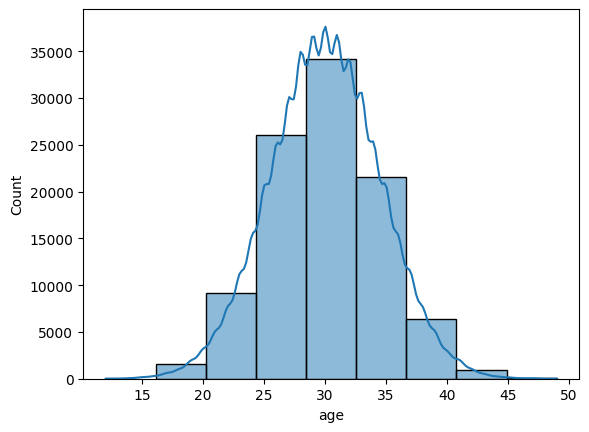

```python
#Plot of the distribution of ages after spliting the customers into a several groups
sns.histplot(df['age'], bins=bounds, kde=True)
plt.show()
```

```python
#Computing the number of customers on every interval(e.g. groups)
count_bounds = [0] * len(bounds)
#Compute the number of entries on the first and the last intervals
count_bounds[0] = sum(age < bounds[0])
count_bounds[len(bounds) - 1] = sum(age >= bounds[len(bounds) - 1])
#Compute the of number of entries on the rest of intervals
for i in range(1, len(bounds)):
    count_bounds[i] = sum(age < bounds[i]) - sum(age < bounds[i - 1])
print("Observed number of customers on every interval", count_bounds)
```

```
Observed number of customers on every interval [np.int64(125), np.int64(1576), np.int64(9189), np.int64(26026), np.int64(34182), np.int64(21564), np.int64(6370), np.int64(906), np.int64(61)]
```

```python
#Compute Z score for every interval
z_score = [0] * len(bounds)
for i in range(len(bounds)):
    z_score[i] = (bounds[i] - age_mean)/age_std
print("Z-score for every interval", z_score)
```

[output not shown]

```python
#Computing the area till the particular Z-score
area_under = [0] * len(bounds)
for i in range(len(bounds)):
    area_under[i] = stats.norm.cdf(z_score[i])
print("Area under the curve for every Z-score", area_under)
```

[output not shown]

```python
#Computing the theoretical value of the area under the curve for every interaval
area_inside = [0] * len(bounds)
area_inside[0] = round(area_under[0], 8)

for i in range(1, len(bounds)):
    area_inside[i] = round(area_under[i] - area_under[i - 1], 8)
print("Area under the curve for every interval", area_inside)
```

```
Area under the curve for every interval [np.float64(0.00096574), np.float64(0.01355151), np.float64(0.08833528), np.float64(0.26110131), np.float64(0.35158647), np.float64(0.21597837), np.float64(0.06038959), np.float64(0.00764535), np.float64(0.0004352)]
```

```python
#Computing the number of all customers
count_all_customes = sum(count_bounds)

#Computing the expected number of client for every interval
expect_count_bounds = [0] * len(bounds)
for i in range(len(area_under)):
    expect_count_bounds[i] = area_inside[i] * count_all_customes
print("Expected number of customers on every interval", expect_count_bounds)
```

```
Expected number of customers on every interval [np.float64(96.57303426), np.float64(1355.13744849), np.float64(8833.439664720001), np.float64(26109.869898689998), np.float64(35158.295413529995), np.float64(21597.62102163), np.float64(6038.89861041), np.float64(764.52735465), np.float64(43.5195648)]
```

```python
observed_freq = np.array(count_bounds)
expected_freq = np.array(expect_count_bounds)

chi_square_stat = np.sum((observed_freq - expected_freq) ** 2 / expected_freq)

# Degrees of freedom
degreef = len(bounds) - 1

# Critical value at 0.05 significance level
critical_value = stats.chi2.ppf(0.95, degreef)

# Compare chi-square statistic to critical value
print("Chi-square statistic:", chi_square_stat)
print("Critical value:", critical_value)

if chi_square_stat > critical_value:
    print("Reject the null hypothesis in favor of the alternative hyphothesis.")
else:
    print("Fail to reject the null hypothesis.")
```

```
Chi-square statistic: 137.46210975480778
Critical value: 15.50731305586545
Reject the null hypothesis in favor of the alternative hyphothesis.
```

## Part 2: Linear regression model

The natural question that may arise is "Is there any correlation between the level of income and the amount of money a person spends on a purchase?". Let us investigate it and try to build a linear relation between the level of income and the amount of money spent on the purchases.

$H_0:$ *there is **no** relationship between the predictor variable and the response variable;*

$H_A:$ *there is a relationship between the predictor variable and the response variable;*

The **significance level** in our testing is **0.05**.

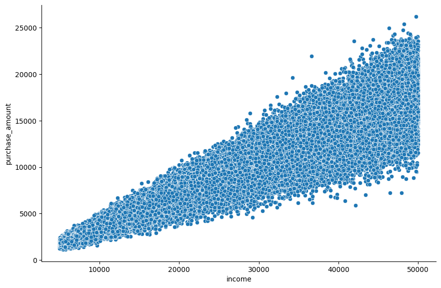

```python
# Creating a visualization
plot = sns.relplot(
    data=df,
    x="income", y="purchase_amount"
)
plot.figure.set_size_inches(10, 6)

plt.show()
```

```python
#Removing the rows where the data is not full
df = df.dropna(subset=['income', 'purchase_amount'])

#Creating vectors for linear regression
x = df['income'].to_numpy().reshape((-1, 1))
y = df['purchase_amount'].to_numpy()

#Check that the sizes of the vectors is appropriate for linear regression
print(x.shape)
print(y.shape)
```

```
(100000, 1)
(100000,)
```

We prepared vectors for building the model. Now, the OLS technique is applied.

```python
# Add a constant term for intercept
x_with_const = sm.add_constant(x)

# Fit the model using statsmodels
model = sm.OLS(y, x_with_const).fit()

# Get the summary of the model
summary = model.summary()
print(summary)
```

```
                            OLS Regression Results
==============================================================================
Dep. Variable:                      y   R-squared:                       0.900
Model:                            OLS   Adj. R-squared:                  0.900
Method:                 Least Squares   F-statistic:                 8.954e+05
Date:                Sat, 03 Aug 2024   Prob (F-statistic):               0.00
Time:                        08:04:47   Log-Likelihood:            -8.7462e+05
No. Observations:              100000   AIC:                         1.749e+06
Df Residuals:                   99998   BIC:                         1.749e+06
Df Model:                           1
Covariance Type:            nonrobust
==============================================================================
                 coef    std err          t      P>|t|      [0.025      0.975]
------------------------------------------------------------------------------
const         -2.2924     11.263     -0.204      0.839     -24.368      19.783
x1             0.3502      0.000    946.262      0.000       0.350       0.351
==============================================================================
Omnibus:                     4367.454   Durbin-Watson:                   1.995
Prob(Omnibus):                  0.000   Jarque-Bera (JB):            15075.984
Skew:                           0.006   Prob(JB):                         0.00
Kurtosis:                       4.902   Cond. No.                     7.13e+04
==============================================================================

Notes:
[1] Standard Errors assume that the covariance matrix of the errors is correctly specified.
[2] The condition number is large, 7.13e+04. This might indicate that there are
strong multicollinearity or other numerical problems.
```

```python
#Parametrs of the line from the model
interception_val = model.params[0]
slope_val = model.params[1]

print("Interception value: ", interception_val)
print("Slope value: ", slope_val)
```

```
Interception value:  -2.2924034224774594
Slope value:  0.3502321821035464
```

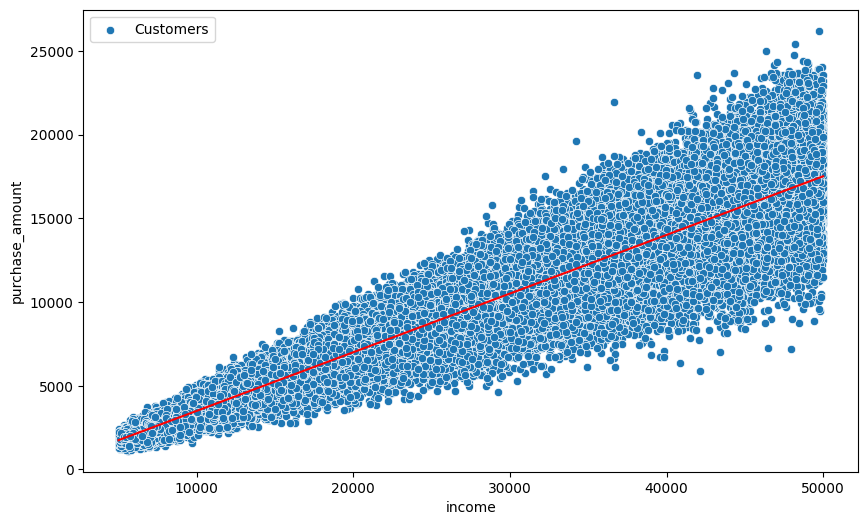

```python
# Generate predicted values
x_pred = np.linspace(x.min(), x.max(), 100)
y_pred = interception_val + slope_val * x_pred

# Set the figure size
plt.figure(figsize=(10, 6))

# Plot the original data
sns.scatterplot(data=df, x=df['income'], y=df['purchase_amount'],  label='Customers')

# Plot the trend line
plt.plot(x_pred, y_pred, color='red', label='Trend Line')
```

```python
p_val = model.pvalues
r_sq = model.rsquared
print("p-value: ", p_val)
print("Coefficient  of determination: ", r_sq)
```

```
p-value:  [0.83872183 0.        ]
Coefficient  of determination:  0.8995408123959152
```

Although the range of customers is wide, the line obtained from the model illustrates the trend and fits pretty well, especially for customers with lower incomes. The coefficient of determination also shows that.